# Laboratory 3

Collin Dabbieri

9/12/2019

# Task 1

```r
getwd()
```

```
## [1] "/home/collindabbieri/Documents/AppliedRegressionAnalysis/Labs/Lab3"
```

# Task 2

```r
library(readxl)
insulation=read_excel("/home/collindabbieri/Documents/AppliedRegressionAnalysis/Dataxls/Excel/INSULATION.xls")

head(insulation)
```

```
## # A tibble: 5 x 2
##   PRESS_X COMP_Y
##     <dbl>  <dbl>
## 1       1      1
## 2       2      1
## 3       3      2
## 4       4      2
## 5       5      4
```

```r
getwd()
```

```
## [1] "/home/collindabbieri/Documents/AppliedRegressionAnalysis/Labs/Lab3"
```

# Task 3

From page 558 in MS

General form of a Multiple Regression Model
$$y = \beta_0 + \beta_1x_1+ \beta_2x_2 + ... + \beta_kx_k + \epsilon$$
where y is the dependent variable $x_1,x_2,...,x_k$ are the independent variables $E(y)=\beta_0+\beta_1x_1+\beta_2x_2+...+\beta_kx_k$ is the deterministic portion of the model. $\beta_i$ determines the contribution of the independent variable $x_i$

The model is also called a general linear model because E(y) is a linear function of the unknown parameters, $\beta_0,\beta_1,...$

An example of a nonlinear model would be $E(y)=\beta_0e^{-\beta_1x}$

The model formula appropriate to the INSULATION data is

$y=\beta_0+\beta_1x_1$

# Task 4

Write down the six steps in analyzing a multiple regression model

from page 559 in MS

1. Hypothesize the deterministic component of the model. This relates the mean, E(y), to the independent variables $x_1,x_2,...,x_k$. This involves the choice of the independent variables to be included in the model
2. Use the sample data to estimate $\beta_0,\beta_1,...,\beta_k$
3. Specify the probability distribution of the random error term, $\epsilon$, and estimate the standard deviation of this distribution, $\sigma$.
4. Check that the assumptions on $\epsilon$ are satisfied, and make model modifications if necessary.
5. Statistically evaluate the usefulnees of the model.
6. When satisfied that the model is useful, use it for prediction, estimation, and other purposes.

Write down the four assumptions of a Multiple Regression Analysis.

From page 560 in MS

1. The mean of $\epsilon$ is 0, meaning the E(y) is equivalent to the deterministic portion of the model.
2. For all settings of the independent variables $x_1,x_2,...,x_k$, the variance of $\epsilon$ is constant. $V(\epsilon)=\sigma^2$
3. The probability distribution of $\epsilon$ is normal.
4. The random errors are independent.

For the INSULATION data, how many independent variables are there? 1

Using the s20x library and the function normcheck()-what do you conclude?

```r
library(s20x)

#normcheck takes a fitted lm object

inslm=lm(lm(COMP_Y ~ PRESS_X, data = insulation))

check=normcheck(inslm,shapiro.wilk = TRUE)
```

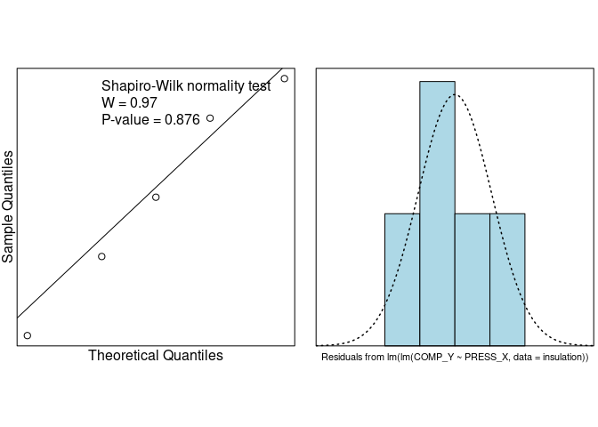

For the Shapiro-Wilk test, the NULL is that the residuals are normally distributed. The p-value for the test is 0.876, so we do not have evidence to conclude that $\epsilon$ is not distributed normal.

# Task 5

Use R to make a Y vector and X design matrix

```r
Y=matrix(,nrow=length(insulation$COMP_Y),ncol=1)
Y[,1]=insulation$COMP_Y
X=matrix(,nrow=length(insulation$COMP_Y),ncol=2)
X[,1]=1
X[,2]=insulation$PRESS_X
Y
```

```
##      [,1]
## [1,]    1
## [2,]    1
## [3,]    2
## [4,]    2
## [5,]    4
```

```r
X
```

```
##      [,1] [,2]
## [1,]    1    1
## [2,]    1    2
## [3,]    1    3
## [4,]    1    4
## [5,]    1    5
```

Find the MLR beta estimates from the formula on page 562.

$$\hat{\beta}=(X'X)^{-1}X'Y$$

```r
betahat=solve(t(X)%*%X)%*%t(X)%*%Y
rownames(betahat)=c("beta0","beta1")
betahat
```

```
##       [,1]
## beta0 -0.1
## beta1  0.7
```

```r
mybeta=function(X,Y){
  betahat=solve(t(X)%*%X)%*%t(X)%*%Y
  return(betahat)
}
mybeta(X,Y)
```

```
##      [,1]
## [1,] -0.1
## [2,]  0.7
```

lm will also give values for $\hat{\beta}$

```r
summary(inslm)
```

```
##
## Call:
## lm(formula = lm(COMP_Y ~ PRESS_X, data = insulation))
##
## Residuals:
##          1          2          3          4          5
##  4.000e-01 -3.000e-01 -5.551e-17 -7.000e-01  6.000e-01
##
## Coefficients:
##             Estimate Std. Error t value Pr(>|t|)
## (Intercept)  -0.1000     0.6351  -0.157   0.8849
## PRESS_X       0.7000     0.1915   3.656   0.0354 *
## ---
## Signif. codes:  0 '***' 0.001 '**' 0.01 '*' 0.05 '.' 0.1 ' ' 1
##
## Residual standard error: 0.6055 on 3 degrees of freedom
## Multiple R-squared:  0.8167, Adjusted R-squared:  0.7556
## F-statistic: 13.36 on 1 and 3 DF,  p-value: 0.03535
```

These values for $\hat{\beta}$ agree with the values I calculated.

# Task 6

From table 11.3 on page 563

```r
comp=c(1,1,2,2,4)
temp=c(1,2,2,4,3)
press=c(1,2,3,4,5)

Y=matrix(,nrow=length(comp),ncol=1)
Y[,1]=comp
X=matrix(,nrow=length(comp),ncol=3)
X[,1]=1
X[,2]=press
X[,3]=temp

Y
```

```
##      [,1]
## [1,]    1
## [2,]    1
## [3,]    2
## [4,]    2
## [5,]    4
```

```r
X
```

```
##      [,1] [,2] [,3]
## [1,]    1    1    1
## [2,]    1    2    2
## [3,]    1    3    2
## [4,]    1    4    4
## [5,]    1    5    3
```

```r
solve(t(X)%*%X)%*%t(X)%*%Y
```

```
##       [,1]
## [1,]  0.35
## [2,]  1.15
## [3,] -0.75
```

```r
mybeta(X,Y)
```

```
##       [,1]
## [1,]  0.35
## [2,]  1.15
## [3,] -0.75
```

```r
y.lm2=lm(comp~press+temp)
summary(y.lm2)
```

```
##
## Call:
## lm(formula = comp ~ press + temp)
##
## Residuals:
##     1     2     3     4     5
##  0.25 -0.15 -0.30  0.05  0.15
##
## Coefficients:
##             Estimate Std. Error t value Pr(>|t|)
## (Intercept)   0.3500     0.3640   0.962   0.4377
## press         1.1500     0.1803   6.379   0.0237 *
## temp         -0.7500     0.2500  -3.000   0.0955 .
## ---
## Signif. codes:  0 '***' 0.001 '**' 0.01 '*' 0.05 '.' 0.1 ' ' 1
##
## Residual standard error: 0.3162 on 2 degrees of freedom
## Multiple R-squared:  0.9667, Adjusted R-squared:  0.9333
## F-statistic:    29 on 2 and 2 DF,  p-value: 0.03333
```

The beta estimates agree.

# Task 7

```r
#dependent is a matrix with nrow=N and ncol=number of dependent variables
#if number of dependent variables is 1, dependent can be a vector
#independent is a vector with length N
#Where N is the number of data points
mybetafromdata=function(dependent,independent){
  if(is.null(dim(dependent))){
    #dependent is a vector
    numdependent=1
    N=length(dependent)
  } else {
    #dependent is a matrix
    N=dim(dependent)[1]
    numdependent=dim(dependent)[2]
  }


  #create design matrix
  X=matrix(,nrow=N,ncol=numdependent+1)

  X[,1]=1

  for(i in 1:numdependent){
    if(numdependent==1){
      #dependent is a vector
      X[,i+1]=dependent
    } else{
      X[,i+1]=dependent[,i]
    }

  }

  Y=matrix(,nrow=N,ncol=1)
  Y[,1]=independent


  #calculate betahat

  betahat=solve(t(X)%*%X)%*%t(X)%*%Y


  #plot (if 1 or 2 dependent variables)

  if(numdependent==1){
    plot(dependent,independent,type="p")
    min=min(dependent)
    max=max(dependent)

    x_plot=seq(min,max,by=(max-min)/100)
    lines(x_plot,betahat[1]+betahat[2]*x_plot)
  }
  if(numdependent==2){
    #contour plot
    xmin=min(dependent[,1])
    xmax=max(dependent[,1])
    ymin=min(dependent[,2])
    ymax=max(dependent[,2])
    x_plot=seq(xmin,xmax,by=(xmax-xmin)/100)
    y_plot=seq(ymin,ymax,by=(ymax-ymin)/100)

    z_matrix=matrix(,nrow=length(x_plot),ncol=length(y_plot))
    for(i in 1:length(x_plot)){
      for(j in 1:length(y_plot)){
        x_val=x_plot[i]
        y_val=x_plot[j]
        z_matrix[i,j]=betahat[1]+betahat[2]*x_val+betahat[3]*y_val
      }
    }

    filled.contour(x=x_plot,y=y_plot,z=z_matrix)
    #color=colormap(z=independent)
    #points(dependent[,1],dependent[,2])

    #p<-plot_ly(x=x_plot,y=y_plot,z=z_matrix,type="contour")#%>%
      #add_trace(x=dependent[,1],y=dependent[,2],type="scatter")
    #p

  }

  #If more than 2 dependent variables, plot all combinations of contours


  #return list with data and betahat

  return(list(betahat=betahat,dependent_data=dependent,independent_data=independent))

}
```

```r
#first let's try 1 dependent variable
dependent=press
independent=comp
vals=mybetafromdata(dependent,independent)
```

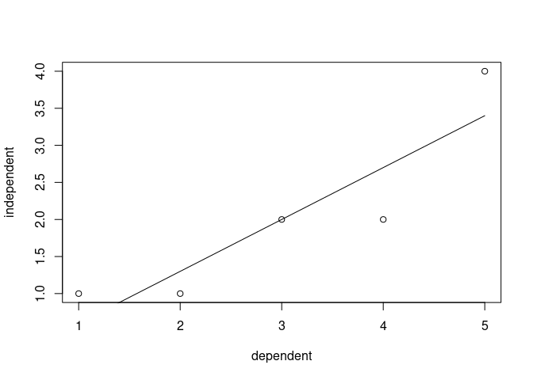

```r
vals
```

```
## $betahat
##      [,1]
## [1,] -0.1
## [2,]  0.7
##
## $dependent_data
## [1] 1 2 3 4 5
##
## $independent_data
## [1] 1 1 2 2 4
```

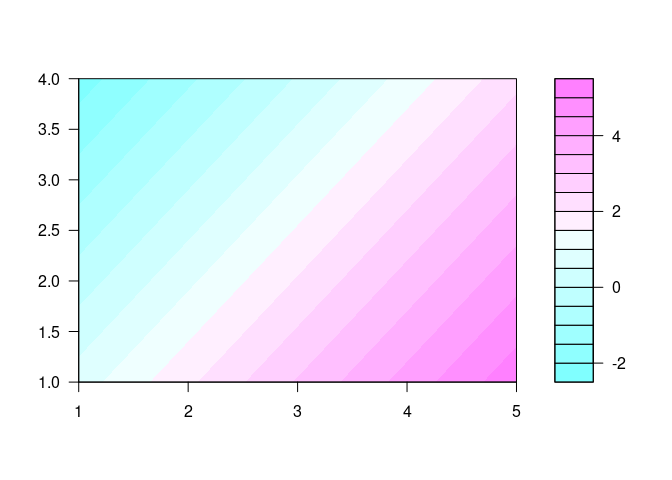

```
## $betahat
##       [,1]
## [1,]  0.35
## [2,]  1.15
## [3,] -0.75
##
## $dependent_data
##      [,1] [,2]
## [1,]    1    1
## [2,]    2    2
## [3,]    3    2
## [4,]    4    4
## [5,]    5    3
##
## $independent_data
## [1] 1 1 2 2 4
```

```r
# Next two dependent variables
dependent=matrix(,nrow=length(comp),ncol=2)
dependent[,1]=press
dependent[,2]=temp
independent=comp
mybetafromdata(dependent,independent)
```